# DT: arrange(), select(), mutate()

D. Howell

9/4/2020

## Intro

On Wednesday, we learned how to select rows based on their values using the filter() function from the dplyr package. Now we look into a few more transformation functions from that package:

- **select()** - move, drop, and rename columns
- **mutate()** - create new columns based on existing column values
- **arrange()** - reorder rows based on column values

We're continuing with the colleges data sets that were introduced on Wednesday. Link to the data [here.](https://github.com/rfordatascience/tidytuesday/blob/master/data/2020/2020-03-10/readme.md)

Let's begin by reading in the data and loading our packages

```r
library(readr)
library(dplyr)

# reading in the tuition cost data from github using the code supplied on the README.md file
tuition_cost <- read_csv('https://raw.githubusercontent.com/rfordatascience/tidytuesday/master/data/2020/2020-03-10/tuition_cost.csv')
# reading in the salary potential data from github using the code supplied on the README.md file
salary_potential <- read_csv('https://raw.githubusercontent.com/rfordatascience/tidytuesday/master/data/2020/2020-03-10/salary_potential.csv')

# we haven't covered joins in detail yet - but just know that this code is putting the two data sets together by the school name column. And because it's an inner join (instead of left, right, outer, etc.), it's dropping rows from either data set that do not appear in the other data set.
df <- inner_join(tuition_cost, salary_potential)

names(df)
```

```
##  [1] "name"                      "state"
##  [3] "state_code"                "type"
##  [5] "degree_length"             "room_and_board"
##  [7] "in_state_tuition"          "in_state_total"
##  [9] "out_of_state_tuition"      "out_of_state_total"
## [11] "rank"                      "state_name"
## [13] "early_career_pay"          "mid_career_pay"
## [15] "make_world_better_percent" "stem_percent"
```

```r
str(df)
```

```
## tibble [728 × 16] (S3: spec_tbl_df/tbl_df/tbl/data.frame)
##  $ name                     : chr [1:728] "Adams State University" "Adventist University of Health Sciences" "Agnes Scott College" "Alabama State University" ...
##  $ state                    : chr [1:728] "Colorado" "Florida" "Georgia" "Alabama" ...
##  $ state_code               : chr [1:728] "CO" "FL" "GA" "AL" ...
##  $ type                     : chr [1:728] "Public" "Private" "Private" "Public" ...
##  $ degree_length            : chr [1:728] "4 Year" "4 Year" "4 Year" "4 Year" ...
##  $ room_and_board           : num [1:728] 8782 4200 12330 5422 7300 ...
##  $ in_state_tuition         : num [1:728] 9440 15150 41160 11068 20830 ...
##  $ in_state_total           : num [1:728] 18222 19350 53490 16490 28130 ...
##  $ out_of_state_tuition     : num [1:728] 20456 15150 41160 19396 20830 ...
##  $ out_of_state_total       : num [1:728] 29238 19350 53490 24818 28130 ...
##  $ rank                     : num [1:728] 16 14 14 20 3 1 18 7 10 5 ...
##  $ state_name               : chr [1:728] "Colorado" "Florida" "Georgia" "Alabama" ...
##  $ early_career_pay         : num [1:728] 44400 51600 46000 39800 50300 81000 49700 52100 40900 51600 ...
##  $ mid_career_pay           : num [1:728] 81400 89800 83600 71500 90000 ...
##  $ make_world_better_percent: num [1:728] 56 88 57 61 67 82 62 44 67 NA ...
##  $ stem_percent             : num [1:728] 3 5 26 16 6 2 2 23 19 0 ...
##  - attr(*, "spec")=
##   .. cols(
##   ..   name = col_character(),
##   ..   state = col_character(),
##   ..   state_code = col_character(),
##   ..   type = col_character(),
##   ..   degree_length = col_character(),
##   ..   room_and_board = col_double(),
##   ..   in_state_tuition = col_double(),
##   ..   in_state_total = col_double(),
##   ..   out_of_state_tuition = col_double(),
##   ..   out_of_state_total = col_double()
##   .. )
```

```r
summary(df)
```

```
##      name              state            state_code            type
##  Length:728         Length:728         Length:728         Length:728
##  Class :character   Class :character   Class :character   Class :character
##  Mode  :character   Mode  :character   Mode  :character   Mode  :character
##
##
##
##
##  degree_length      room_and_board  in_state_tuition in_state_total
##  Length:728         Min.   : 1698   Min.   : 4118    Min.   : 4258
##  Class :character   1st Qu.: 8931   1st Qu.: 9930    1st Qu.:19388
##  Mode  :character   Median :10494   Median :25506    Median :34116
##                     Mean   :10882   Mean   :26272    Mean   :36586
##                     3rd Qu.:12862   3rd Qu.:40076    3rd Qu.:52183
##                     Max.   :18156   Max.   :58230    Max.   :75003
##                     NA's   :38
##  out_of_state_tuition out_of_state_total      rank        state_name
##  Min.   : 4118        Min.   : 6670      Min.   : 1.00   Length:728
##  1st Qu.:20682        1st Qu.:29536      1st Qu.: 5.00   Class :character
##  Median :28844        Median :38780      Median :11.00   Mode  :character
##  Mean   :30656        Mean   :40971      Mean   :11.57
##  3rd Qu.:40576        3rd Qu.:52683      3rd Qu.:17.00
##  Max.   :58230        Max.   :75003      Max.   :25.00
##
##  early_career_pay mid_career_pay   make_world_better_percent  stem_percent
##  Min.   :32500    Min.   : 60100   Min.   :33.00             Min.   :  0.00
##  1st Qu.:45400    1st Qu.: 81200   1st Qu.:48.00             1st Qu.:  7.00
##  Median :49600    Median : 89200   Median :52.00             Median : 13.00
##  Mean   :50978    Mean   : 92139   Mean   :53.63             Mean   : 16.68
##  3rd Qu.:55000    3rd Qu.:100150   3rd Qu.:58.00             3rd Qu.: 22.00
##  Max.   :88800    Max.   :158200   Max.   :94.00             Max.   :100.00
##                                    NA's   :26
```

### select()

Some data sets don't have enough variables to derive useful insights. Most of the time, however, this is not the case. Data sets in the "real world" often serve as the base for several different analyses, all with different goals and purposes. The best practice when beginning to work with one of these data sets is to ask yourself what information you want to try to get from the data set, and which of the columns might help you get there. Then you drop all the columns that are irrelevant to your analysis. This is a minor step because most of the time you can get by without dropping columns, but dropping unnecessary variables makes your programs faster and it makes your data set easier to understand (think "succinctness").

So let's look it the summary again and then select the columns we need and/or drop the columns we don't need.

```r
summary(df)
```

```
##      name              state            state_code            type
##  Length:728         Length:728         Length:728         Length:728
##  Class :character   Class :character   Class :character   Class :character
##  Mode  :character   Mode  :character   Mode  :character   Mode  :character
##
##
##
##
##  degree_length      room_and_board  in_state_tuition in_state_total
##  Length:728         Min.   : 1698   Min.   : 4118    Min.   : 4258
##  Class :character   1st Qu.: 8931   1st Qu.: 9930    1st Qu.:19388
##  Mode  :character   Median :10494   Median :25506    Median :34116
##                     Mean   :10882   Mean   :26272    Mean   :36586
##                     3rd Qu.:12862   3rd Qu.:40076    3rd Qu.:52183
##                     Max.   :18156   Max.   :58230    Max.   :75003
##                     NA's   :38
##  out_of_state_tuition out_of_state_total      rank        state_name
##  Min.   : 4118        Min.   : 6670      Min.   : 1.00   Length:728
##  1st Qu.:20682        1st Qu.:29536      1st Qu.: 5.00   Class :character
##  Median :28844        Median :38780      Median :11.00   Mode  :character
##  Mean   :30656        Mean   :40971      Mean   :11.57
##  3rd Qu.:40576        3rd Qu.:52683      3rd Qu.:17.00
##  Max.   :58230        Max.   :75003      Max.   :25.00
##
##  early_career_pay mid_career_pay   make_world_better_percent  stem_percent
##  Min.   :32500    Min.   : 60100   Min.   :33.00             Min.   :  0.00
##  1st Qu.:45400    1st Qu.: 81200   1st Qu.:48.00             1st Qu.:  7.00
##  Median :49600    Median : 89200   Median :52.00             Median : 13.00
##  Mean   :50978    Mean   : 92139   Mean   :53.63             Mean   : 16.68
##  3rd Qu.:55000    3rd Qu.:100150   3rd Qu.:58.00             3rd Qu.: 22.00
##  Max.   :88800    Max.   :158200   Max.   :94.00             Max.   :100.00
##                                    NA's   :26
```

It's looking like we need * name * out of state tuition * early career pay

The select() function takes arguments in exactly the same way as dplyr::filter(). I'm going to use the pipe format because that's my preference.

Note that we want to preserve our original data by not overwriting that object. So we need to name this derivative data set something different, say, df2.

```r
# selection by defining what you want to keep
df2 <- df %>%
        select(name, out_of_state_tuition, early_career_pay)
summary(df2)
```

```
##      name           out_of_state_tuition early_career_pay
##  Length:728         Min.   : 4118        Min.   :32500
##  Class :character   1st Qu.:20682        1st Qu.:45400
##  Mode  :character   Median :28844        Median :49600
##                     Mean   :30656        Mean   :50978
##                     3rd Qu.:40576        3rd Qu.:55000
##                     Max.   :58230        Max.   :88800
```

```r
# selection by defining what you want to get rid of.
df2a <- df %>%
          select(-(state:in_state_total), -(out_of_state_total:state_name), -(mid_career_pay:stem_percent))
summary(df2a)
```

```
##      name           out_of_state_tuition early_career_pay
##  Length:728         Min.   : 4118        Min.   :32500
##  Class :character   1st Qu.:20682        1st Qu.:45400
##  Mode  :character   Median :28844        Median :49600
##                     Mean   :30656        Mean   :50978
##                     3rd Qu.:40576        3rd Qu.:55000
##                     Max.   :58230        Max.   :88800
```

Perfect.

### mutate()

Deriving calculated fields is in the DNA of data analysis. As an analyst, you do it so much that you begin to not even view it as a task after a while. It quickly becomes second nature. There are several ways to derive a new column, but it's simplest to stick with the dplyr package, which means using mutate()

```r
df3 <- df2 %>%
        mutate(
          roi = round((df2$early_career_pay / df2$out_of_state_tuition - 1) * 100,2)
        )

summary(df3)
```

```
##      name           out_of_state_tuition early_career_pay      roi
##  Length:728         Min.   : 4118        Min.   :32500    Min.   : -10.23
##  Class :character   1st Qu.:20682        1st Qu.:45400    1st Qu.:  31.36
##  Mode  :character   Median :28844        Median :49600    Median :  67.00
##                     Mean   :30656        Mean   :50978    Mean   :  99.38
##                     3rd Qu.:40576        3rd Qu.:55000    3rd Qu.: 134.30
##                     Max.   :58230        Max.   :88800    Max.   :1204.03
```

### arrange()

Reordering the rows of a data set can come in handy often. Namely, the best use of this function for me has been in odering the way observations show up in visualizations. But here, we first want to use it to order the schools from best to worse ROI so that we can add another column for rankings.

arrange is just like the other dplyr functions we've looked at, but it's important to note that the default sorting method is always least to greatest (and A to Z). You can easily change that, and we will need to do it here to get greatest to least.

```r
df4 <- df3 %>%
        arrange(roi)

head(df4)
```

```
## # A tibble: 6 x 4
##   name                  out_of_state_tuition early_career_pay    roi
##   <chr>                                <dbl>            <dbl>  <dbl>
## 1 Bennington College                   54360            48800 -10.2
## 2 Beloit College                       50040            47400  -5.28
## 3 Colorado College                     55470            53100  -4.27
## 4 Oberlin College                      55054            53100  -3.55
## 5 Lewis & Clark College                50934            50000  -1.83
## 6 Kenyon College                       55930            55000  -1.66
```

Looks like it ordered from least to greatest. Enter the desc() function to change it.

```r
df4 <- df3 %>%
        arrange(
          desc(roi)
        )

head(df4)
```

```
## # A tibble: 6 x 4
##   name                            out_of_state_tuition early_career_pay   roi
##   <chr>                                          <dbl>            <dbl> <dbl>
## 1 Brigham Young University-Idaho                  4118            53700 1204.
## 2 Brigham Young University-Hawaii                 5560            51700  830.
## 3 Western Governors University                    6670            54500  717.
## 4 Minot State University                          7064            44500  530.
## 5 Chadron State College                           7196            42300  488.
## 6 Alcorn State University                         7144            40900  473.
```

That's more like it!

Now the data looks like we want it to. We just need to add a rank column, which is super easy.

```r
df5 <- df4 %>%
        mutate(rank = 1:nrow(df4))
```

Let's find ORU...

```r
df5 %>% filter(name == 'Oral Roberts University')
```

```
## # A tibble: 1 x 5
##   name                    out_of_state_tuition early_career_pay   roi  rank
##   <chr>                                  <dbl>            <dbl> <dbl> <int>
## 1 Oral Roberts University                27728            45900  65.5   368
```

Let's get the rankings of some schools in percentiles.

```r
# Let's get the percentiles (the higher the better)
round((1-df5$rank[df5$name=='Oral Roberts University']/nrow(df5))*100)
```

```
## [1] 49
```

```r
round((1-df5$rank[df5$name=='University of Tulsa']/nrow(df5))*100)
```

```
## [1] 32
```

```r
round((1-df5$rank[df5$name=='Yale University']/nrow(df5))*100)
```

```
## [1] 25
```

```r
round((1-df5$rank[df5$name=='University of Central Oklahoma']/nrow(df5))*100)
```

```
## [1] 79
```

Further exploring, let's crank out some graphs.

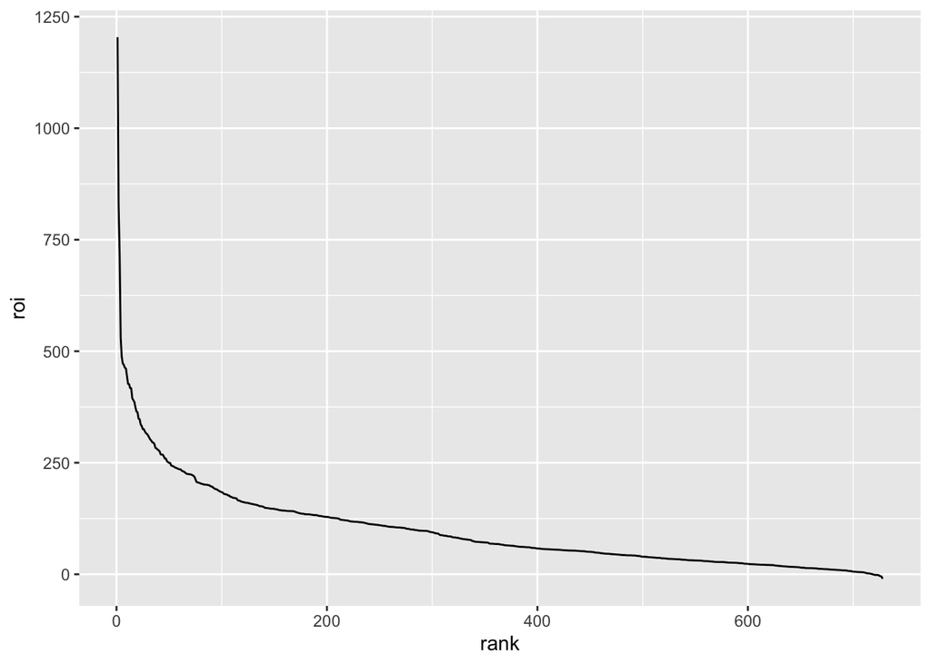

```r
library(ggplot2)

ggplot(df5) +
  geom_line(aes(x = rank, y=roi))
```

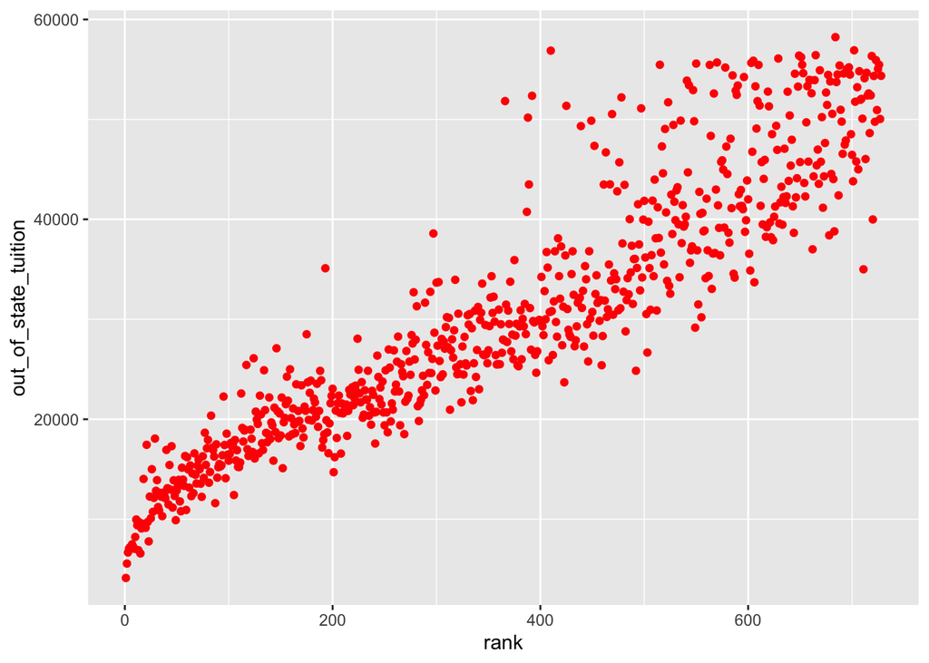

```r
ggplot(df5) +
  geom_point(aes(x = rank, y = out_of_state_tuition), color = 'red')
```

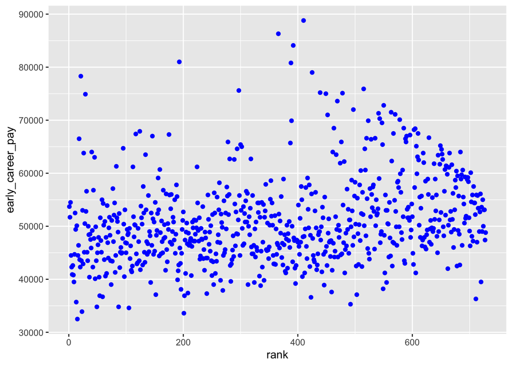

```r
ggplot(df5) +
  geom_point(aes(x = rank, y = early_career_pay), color = 'blue')
```

This analysis does come with several caveats, and it's important for you, as the analyst, to point them out so that people don't misinterpret your analysis. Some of the disclaimers of this analysis so far would include:

- This is out of state tuition and early career pay. I'm sure the results would be different if we chose instead to try to find lifetime earnings data about these schools.
- This does not factor in average scholarships given by the schools, which would probably greatly impact ROI.
- You might have an added constraint that you want to weed out any schools where the early career salary is less than a set amount. A program could cost $10 and the starting salary could be 12,000 which would be an incredible ROI, but that would still put you below the poverty line.